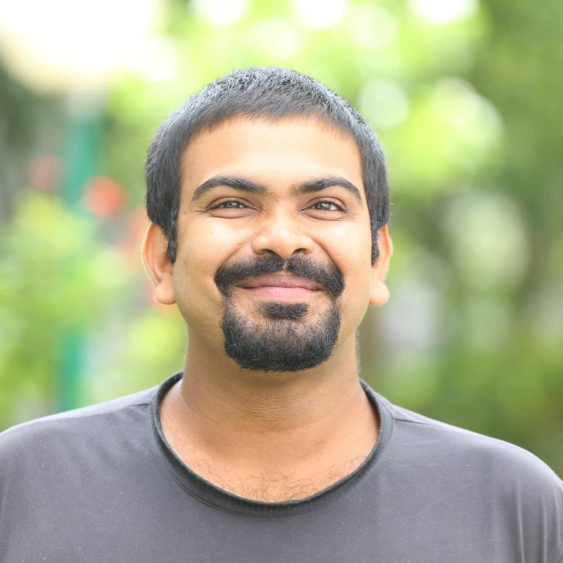

# **Arijit Ghosh** Ph.D.

### **About me**

Currently I am a visiting postdoctoral fellow at the [Laboratory of Systems Genetics, SBC, NHLBI at Bethesda, Maryland](https://www.nhlbi.nih.gov/science/systems-genetics#Meet-the-Team). I study the interaction between the circadian clock and sleep genetic networks, and how these interactions shape various behavior and physiological responses. During my PhD, I worked on understanding the genetic and molecular mechanisms underlying complex behaviors, specifically timing of a behavior at the [Chronobiology and Behavioural Neurogenetics Laboratory](https://www.jncasr.ac.in/faculty/sheeba), JNCASR. My studies use diverse methodologies - from statistical modeling of behavior to next-generation sequencing. Previously, I have also worked on thermo-sensitive Transient Receptor Potential (TRP) channels and their role in osteogenesis, using rodent models, primary bone cells, pharmacological modulators, and molecular dynamics during my masters studies at [NISER](https://www.niser.ac.in/).

Apart from my work in the lab, I am a leisure photographer, connoisseur of sci-fi (old and new) and good food! For a full list of my publications, check out my [Google Scholar profile](https://scholar.google.co.in/citations?user=Nuaw_FoAAAAJ&hl=en), for my publicly available codes, check out my [Github page](https://github.com/orijitghosh).

### **Education**

- **Jawaharlal Nehru Centre for Advanced Scientific Research** | Bangalore, India  
  *Graduate student at the Neuroscience Unit* | August 2016 - June 2022
- **Homi Bhaba National Institute (Program conducted at National Institute of Science Education and Research)** | Bhubaneswar, India  
  *Integrated MSc in Life Sciences* | August 2011 - May 2016

### **Publications**

###### *(asterisk) : First OR joint first author

1. Sara Milojevic, **Arijit Ghosh**, Vedrana Makevic, Maja Stojkovic, Maria Capovilla, Tomislav Tosti, Dejan B. Budimirovic, Dragana Protic. “Circadian Rhythm and Sleep Analyses in a Fruit Fly Model of Fragile X Syndrome Using a Video-Based Automated Behavioral Research System”. *International Journal of Molecular Sciences*, 25(14):7949 (2024). [Link](https://www.mdpi.com/1422-0067/25/14/7949)
2. Narendra Pratap Singh, **Arijit Ghosh**, Susan T. Harbison. “The Genetics of sleep in *Drosophila*” in Genetics of Sleep and Sleep Disorders. In Philip Gehrman, Alex C. Keene, Struan F. Grant (eds) *Genetics of Sleep and Sleep Disorders*, Springer, Cham (2024). [Link](https://link.springer.com/chapter/10.1007/978-3-031-62723-1_2)
3. Tushar Kanta Acharya, Subhashis Pal, *Arijit Ghosh, Shamit Kumar, Naibedya Chattopadhyay, Chandan Goswami. “TRPV4 regulates osteoblast differentiation and mitochondrial function that are relevant for channelopathy”. *Frontiers in Cell and Developmental Biology*, 11 (2023). [Link](https://www.frontiersin.org/journals/cell-and-developmental-biology/articles/10.3389/fcell.2023.1066788/full)
4. *Arijit Ghosh, Vasu Sheeba. “VANESSA – Shiny apps for accelerated time-series analysis and visualization of *Drosophila* circadian rhythm and sleep data.” *Journal of biological rhythms*, 37, no. 2 (2022): 222-231. [Link](https://journals.sagepub.com/doi/full/10.1177/07487304221077662)
5. *Arijit Ghosh, Pragya Sharma, Shephali Dansana, Vasu Sheeba. “Evidence for coevolution of masking and circadian phase in *Drosophila melanogaster*”. *Journal of biological rhythms* 36, no. 3 (2021): 254-270. [Link](https://journals.sagepub.com/doi/full/10.1177/0748730421997262)
6. Tushar Kanta Acharya, Satish Kumar, Nikhil Tiwari, *Arijit Ghosh, Ankit Tiwari, Subhashis Pal, Rakesh Kumar Majhi, Ashutosh Kumar, Rashmita Das, Abhishek Singh, Pradip K. Majhi, Naibedya Chattopadhyay, Luna Goswami, Chandan Goswami. “TRPM8 channel inhibitor-encapsulated hydrogel as a tunable surface for bone tissue engineering”. *Scientific Reports* 11, 3730 (2021). [Link](https://www.nature.com/articles/s41598-021-81041-w)
7. Lakshman Abhilash, **Arijit Ghosh**, and Vasu Sheeba. “Selection for timing of eclosion results in co-evolution of temperature responsiveness in *Drosophila melanogaster*”. *Journal of biological rhythms* 34, no. 6 (2019): 596-609. [Link](https://journals.sagepub.com/doi/full/10.1177/0748730419877315)
8. Nabanita Roy Chattopadhyay, Koustav Chatterjee, Nikhil Tiwari, Sudipta Chakrabarti, Sushil Kumar Sahu, Sankar Deb Roy, **Arijit Ghosh**, R Rajendra Reddy, Piyanki Das, Sudipa Mal, Basab Bijay Karnar, Ashok Kumar Das, Sam Tsering, Komri Riba, Zoreng puii, Eric Zomawia, Y Indibar Singh, Amol Ratnakar Suryawanshi, Abhishek Kumar, Dipyaman Ganguly, Chandan Goswami, Tathagata Choudhuri. “TLR9 polymorphisms might contribute to the ethnicity bias for EBV-infected Nasopharyngeal Carcinoma”. *iScience* 23, no. 3 (2020): 100937. [Link](https://www.sciencedirect.com/science/article/pii/S2589004220301218?via%3Dihub)
9. Somdatta Saha, Samikshya Sucharita, Rakesh Kumar Majhi, Ankit Tiwari, **Arijit Ghosh**, Sunil Kumar Pradhan, Bijay Kumar Patra et al. “TRPA1 is selected as a semi-conserved channel during vertebrate evolution due to its involvement in spermatogenesis”. *Biochemical and biophysical research communications 512*, no. 2 (2019): 295-302. [Link](https://www.sciencedirect.com/science/article/pii/S0006291X19303225?via%3Dihub)
10. Sridhar Sanyasi, Satish Kumar, **Arijit Ghosh**, Rakesh Kumar Majhi, Navneet Kaur, Priyanka Choudhury, Udai P. Singh, Chandan Goswami, and Luna Goswami. “A modified polysaccharide-based hydrogel for enhanced osteogenic maturation and mineralization independent of differentiation factors”. *Macromolecular bioscience* 17, no. 3 (2017): 1600268. [Link](https://onlinelibrary.wiley.com/doi/10.1002/mabi.201600268)
11. Somdatta Saha, *Arijit Ghosh, Nikhil Tiwari, Ashutosh Kumar, Abhishek Kumar, and Chandan Goswami. “Preferential selection of Arginine at the lipid-water-interface of TRPV1 during vertebrate evolution correlates with its snorkeling behaviour and cholesterol interaction”. *Scientific reports* 7, no. 1 (2017): 1-21. [Link](https://www.nature.com/articles/s41598-017-16780-w)
12. *Arijit Ghosh, Navneet Kaur, Abhishek Kumar, and Chandan Goswami. “Why individual thermo sensation and pain perception varies? Clue of disruptive mutations in TRPVs from 2504 human genome data”. *Channels* 10, no. 5 (2016): 339-345. [Link](https://www.tandfonline.com/doi/full/10.1080/19336950.2016.1162365)
13. Rakesh Kumar Majhi, Somdatta Saha, Ashutosh Kumar, **Arijit Ghosh**, Nirlipta Swain, Luna Goswami, Pratyush Mohapatra et al. “Expression of temperature-sensitive ion channel TRPM8 in sperm cells correlates with vertebrate evolution”. *PeerJ* 3 (2015): e1310. [Link](https://peerj.com/articles/1310/)

### **Work experience**

###### **Postdoctoral research (2022-Now)**

- Developed hidden Markov model based frameworks to classify fly sleep into distinct states
- Developed algorithms to extract circadian timeseries parameters from large datasets
- Conducted a genome wide association study of circadian phases in the *Drosophila* Genetic Reference Panel
- Contributed to a book chapter on “The genetics of sleep in *Drosophila*”, and currently writing multiple research articles on original research work

###### **Graduate research (2016-2022)**

- Conducted original research on classical chronobiology, sleep, and population genomics of circadian phases and published research articles
- Published open source apps for high throughout automated analysis of circadian rhythms and sleep
- Contributed to organizing multiple academic conference and science outreach activities on and off campus

###### **Masters and undergraduate research (2013-2016)**

- Established primary bone cell, immune cell, and stem cell cultures in the lab
- Established novel molecular dynamics simulation routines in the lab
- Established novel histological and imaging-focused assays in the lab for bone tissue engineering -Worked collaboratively with other lab members on different bioinformatics projects